# Analysing biomarkers to determine the presence of liver cirrhosis.

## ASDS 6302 final project

### Utkarsh Pant

The aim of this project is to develop Logistic Regression and Support Vector Machine models that can predict the presence of liver cirrhosis on the basis of certain biomarkers. **The original research that produced the dataset also sought to investigate the gender-based disparity in the study of the disease, leading to marked difference in patient treatment and outcomes. Hence, the "imbalance" between data available for male and female patients is a key feature of the dataset.**

```python
import pandas
import numpy

import seaborn
import matplotlib.pyplot as plot

from sklearn.model_selection import train_test_split
from sklearn.linear_model import LogisticRegression
from sklearn.svm import SVC

from sklearn.metrics import accuracy_score, confusion_matrix, roc_curve, roc_auc_score
```

```python
# Load the dataset and assign column names
liver_data = pandas.read_csv("./dataset/ilpd.csv")
liver_data.columns = ["Age",
                      "Gender",
                      "TB",
                      "DB",
                      "Alkphos",
                      "Sgpt",
                      "Sgot",
                      "TP",
                      "ALB",
                      "AGRatio",
                      "Target"]
liver_data.head()
```

|  | Age | Gender | TB | DB | Alkphos | Sgpt | Sgot | TP | ALB | AGRatio | Target |
| --- | --- | --- | --- | --- | --- | --- | --- | --- | --- | --- | --- |
| 0 | 62 | Male | 10.9 | 5.5 | 699 | 64 | 100 | 7.5 | 3.2 | 0.74 | 1 |
| 1 | 62 | Male | 7.3 | 4.1 | 490 | 60 | 68 | 7.0 | 3.3 | 0.89 | 1 |
| 2 | 58 | Male | 1.0 | 0.4 | 182 | 14 | 20 | 6.8 | 3.4 | 1.00 | 1 |
| 3 | 72 | Male | 3.9 | 2.0 | 195 | 27 | 59 | 7.3 | 2.4 | 0.40 | 1 |
| 4 | 46 | Male | 1.8 | 0.7 | 208 | 19 | 14 | 7.6 | 4.4 | 1.30 | 1 |

## Descriptive statistics and data overview

Checking for any NA or otherwise missing values in the dataset:

```python
liver_data.isna().sum()
```

```
Age        0
Gender     0
TB         0
DB         0
Alkphos    0
Sgpt       0
Sgot       0
TP         0
ALB        0
AGRatio    4
Target     0
dtype: int64
```

There appear to be no missing values in the dataset, except for the `AGRatio` column. Upon inspection, we see:

```python
liver_data.loc[pandas.isna(liver_data["AGRatio"]), ]
```

|  | Age | Gender | TB | DB | Alkphos | Sgpt | Sgot | TP | ALB | AGRatio | Target |
| --- | --- | --- | --- | --- | --- | --- | --- | --- | --- | --- | --- |
| 208 | 45 | Female | 0.9 | 0.3 | 189 | 23 | 33 | 6.6 | 3.9 | NaN | 1 |
| 240 | 51 | Male | 0.8 | 0.2 | 230 | 24 | 46 | 6.5 | 3.1 | NaN | 1 |
| 252 | 35 | Female | 0.6 | 0.2 | 180 | 12 | 15 | 5.2 | 2.7 | NaN | 2 |
| 311 | 27 | Male | 1.3 | 0.6 | 106 | 25 | 54 | 8.5 | 4.8 | NaN | 2 |

```python
seaborn.set_theme("paper")
seaborn.set_style("whitegrid")
```

[output not shown]

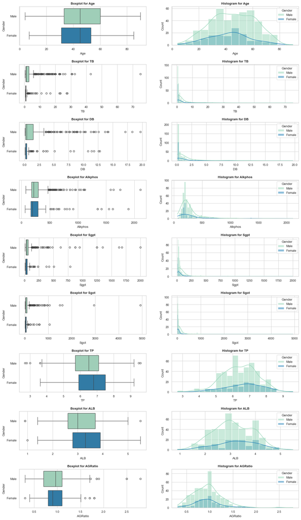

```python
exclude = ["Gender", "Target"]
continuous = [col for col in liver_data.columns if col not in exclude]

figure, axes = plot.subplots(len(continuous), 2, figsize=(15, 3 * len(continuous)))
axes = axes.flatten()

for i, axes in enumerate(axes):
    # Plot boxplot
    if i % 2 == 0:
        seaborn.boxplot(x=liver_data[continuous[i // 2]], ax=axes, palette = 'YlGnBu', y="Gender", data=liver_data)
        axes.set_title(f'Boxplot for {continuous[i // 2]}', fontdict={'fontweight': 'bold'})
    # # Plot histogram
    else:
        seaborn.histplot(x=liver_data[continuous[i // 2]], ax=axes, kde=True, hue="Gender", palette = 'YlGnBu', data=liver_data)
        axes.set_title(f'Histogram for {continuous[i // 2]}', fontdict={'fontweight': 'bold'})

plot.subplots_adjust(hspace=0.5)  # Adjust the spacing between rows
```

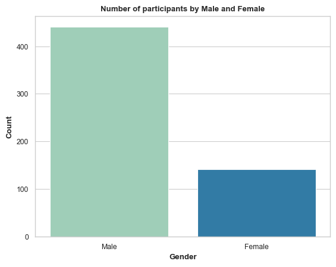

```python
gender_countplot = seaborn.countplot(data = liver_data, x = "Gender", palette = "YlGnBu")
gender_countplot.set_title("Number of participants by Male and Female", fontdict={"fontweight": "bold"})
gender_countplot.set_ylabel("Count", fontdict={"fontweight": "bold"})
gender_countplot.set_xlabel("Gender", fontdict={"fontweight": "bold"})
```

```python
liver_data.loc[liver_data['Target'] == 2, 'Target'] = 0 # healthy
liver_data.loc[liver_data['Target'] == 1, 'Target'] = 1
```

[output not shown]

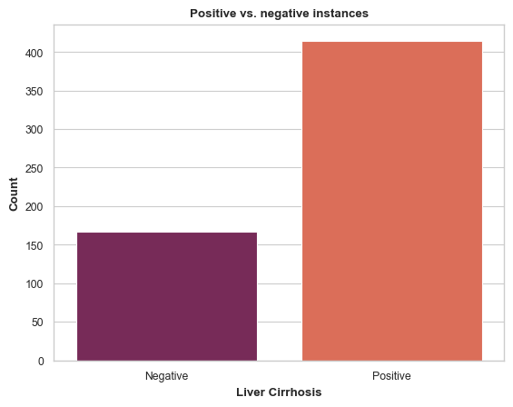

```python
target_countplot = seaborn.countplot(data = liver_data, x = "Target", palette = "rocket")
target_countplot.set_title("Positive vs. negative instances", fontdict={"fontweight": "bold"})
target_countplot.set_ylabel("Count", fontdict={"fontweight": "bold"})
target_countplot.set_xlabel("Liver Cirrhosis", fontdict={"fontweight": "bold"})
target_countplot.set_xticklabels(["Negative", "Positive"])
```

### Correlation analysis + picking significant predictors

[figure not shown]

```python
import matplotlib.pyplot as plot

correlation = liver_data.corr(numeric_only=True)
heatmap = seaborn.heatmap(correlation, annot=True, cmap="rocket")
heatmap.set_title("Correlation heatmap for numeric predictors", fontdict={"fontweight": "bold"})
```

Between the features, we see that `TB` and `DB` are highly correlated, as are `TP` and `ALB`. This is expected, as the former pair are both measures of bilirubin levels, while the latter pair are measures of protein levels. We must drop *one* feature in either pair from our model, in order to reduce redundant information. Hence, we drop `TB` and `TP` from the respective pairs since they are less correlated with `Target` as their counterparts. Similarly, between `Sgpt` and `Sgot`, we drop `Sgot` as it is less correlated with `Target`.

```python
liver_data.drop(['TB', 'TP', 'Sgot'], axis = 1, inplace = True)
liver_data.head()
```

|  | Age | Gender | DB | Alkphos | Sgpt | ALB | AGRatio | Target |
| --- | --- | --- | --- | --- | --- | --- | --- | --- |
| 0 | 62 | Male | 5.5 | 699 | 64 | 3.2 | 0.74 | 1 |
| 1 | 62 | Male | 4.1 | 490 | 60 | 3.3 | 0.89 | 1 |
| 2 | 58 | Male | 0.4 | 182 | 14 | 3.4 | 1.00 | 1 |
| 3 | 72 | Male | 2.0 | 195 | 27 | 2.4 | 0.40 | 1 |
| 4 | 46 | Male | 0.7 | 208 | 19 | 4.4 | 1.30 | 1 |

### Data preprocessing

```python
# encode male as 1 and female as 0
liver_data.loc[liver_data["Gender"] == "Male", "Gender"] = 1
liver_data.loc[liver_data["Gender"] == "Female", "Gender"] = 0
```

```python
# validating our encoding was successful
liver_data["Gender"].value_counts()
```

```
Gender
1    441
0    141
Name: count, dtype: int64
```

Since 2 observations are *Male* and 2 are *Female* participants, we can safely drop these observations from the dataset for simplicity.

```python
liver_data.dropna(subset=["AGRatio"], inplace=True)
```

We can also impute the outliers in our features, so as to base our modelling and analysis *only* on the underlying distributions for each continuous variable. Due to the lack of subject-matter expertise and the simple scope, we cannot determine the "true" values of these outliers, and hence we will impute them with the upper and lower "thresholds".

```python
# imputing outliers

for column in continuous:
    Q1 = numpy.quantile(liver_data[column], 0.25)
    Q3 = numpy.quantile(liver_data[column], 0.75)
    IQR = Q3 - Q1
    lower_bound = Q1 - 1.5 * IQR
    upper_bound = Q3 + 1.5 * IQR
    liver_data.loc[liver_data[column] < lower_bound, column] = lower_bound
    liver_data.loc[liver_data[column] > upper_bound, column] = upper_bound
```

### Scaling the data

```python
from sklearn.preprocessing import StandardScaler

scaler = StandardScaler()
liver_data[continuous] = scaler.fit_transform(liver_data[continuous])

liver_data.head()
```

|  | Age | Gender | DB | Alkphos | Sgpt | ALB | AGRatio | Target |
| --- | --- | --- | --- | --- | --- | --- | --- | --- |
| 0 | 1.064979 | 1 | 2.073315 | 2.098953 | 0.470077 | 0.077750 | -0.676143 | 1 |
| 1 | 1.064979 | 1 | 2.073315 | 2.098953 | 0.350730 | 0.203630 | -0.171698 | 1 |
| 2 | 0.818065 | 1 | -0.486781 | -0.637668 | -1.021760 | 0.329510 | 0.198229 | 1 |
| 3 | 1.682266 | 1 | 1.119554 | -0.519130 | -0.633882 | -0.929292 | -1.819551 | 1 |
| 4 | 0.077321 | 1 | -0.185594 | -0.400593 | -0.872576 | 1.588312 | 1.207119 | 1 |

## Training and testing the models

### Splitting the data into training and testing sets

```python
X = liver_data.drop("Target", axis = 1)
y = liver_data["Target"]

X_train, X_test, y_train, y_test = train_test_split(X, y, test_size = 0.3, random_state = 8093)
```

### Logistic Regression

```python
logisticRegression = LogisticRegression()
logisticRegression.fit(X_train, y_train)

y_pred_lr = logisticRegression.predict(X_test)
```

#### Accuracy

```python
accuracy_lr = accuracy_score(y_test, y_pred_lr)
accuracy_lr
```

```
0.6954022988505747
```

#### Confusion matrix

```python
confusion_matrix_lr = confusion_matrix(y_test, y_pred_lr)
labels = numpy.reshape([f"True Negative: {confusion_matrix_lr[0, 0]}",
                        f"False Positive: {confusion_matrix_lr[0, 1]}",
                        f"False Negative: {confusion_matrix_lr[1, 0]}",
                        f"True Positive: {confusion_matrix_lr[1, 1]}"], (2, 2))
```

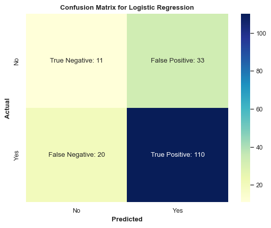

```python
conf_heatmap_lr = seaborn.heatmap(confusion_matrix_lr,
                annot=labels,
                cmap="YlGnBu",
                fmt="",
                xticklabels=["No", "Yes"],
                yticklabels=["No", "Yes"])
conf_heatmap_lr.set_xlabel("Predicted", fontdict={'fontweight': 'bold'})
conf_heatmap_lr.set_ylabel("Actual", fontdict={'fontweight': 'bold'})
conf_heatmap_lr.set_title("Confusion Matrix for Logistic Regression", fontdict={'fontweight': 'bold'})
```

#### ROC Curve and AuC metric

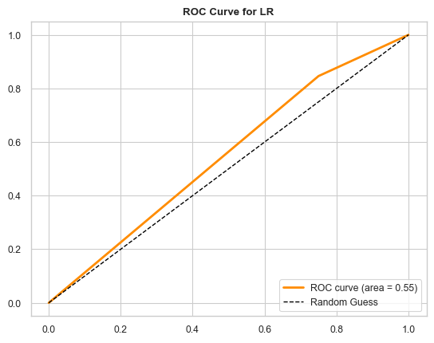

```python
fpr, tpr, thresholds = roc_curve(y_test, y_pred_lr)
roc_auc = roc_auc_score(y_test, y_pred_lr)

plot.figure()
plot.plot(fpr, tpr, color='darkorange', lw=2, label='ROC curve (area = %0.2f)' % roc_auc)
plot.plot([0, 1], [0, 1], color='black', lw=1, linestyle='--', label='Random Guess')
plot.legend(loc='lower right')
plot.grid(True)
plot.title("ROC Curve for LR", fontdict = {"fontweight": "bold"})
plot.show()
```

### Support Vector Machine

```python
svm = SVC(kernel="rbf")
svm.fit(X_train, y_train)

y_pred_svm = svm.predict(X_test)
```

#### Accuracy

```python
accuracy_svm = accuracy_score(y_test, y_pred_svm)
accuracy_svm
```

```
0.7126436781609196
```

#### Confusion matrix

```python
confusion_matrix_svm = confusion_matrix(y_test, y_pred_svm)
labels = numpy.reshape([f"True Negative: {confusion_matrix_svm[0, 0]}",
                        f"False Positive: {confusion_matrix_svm[0, 1]}",
                        f"False Negative: {confusion_matrix_svm[1, 0]}",
                        f"True Positive: {confusion_matrix_svm[1, 1]}"], (2, 2))
```

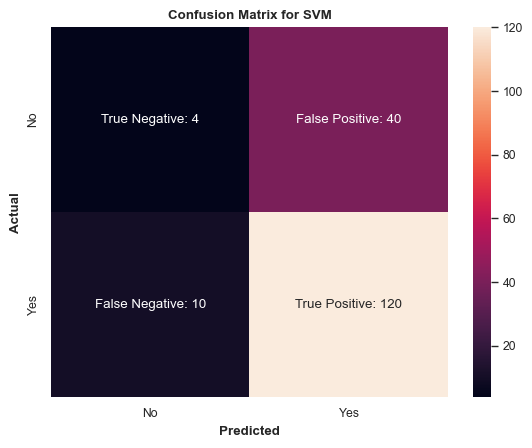

```python
conf_heatmap_svm = seaborn.heatmap(confusion_matrix_svm,
                annot=labels,
                cmap="rocket",
                fmt="",
                xticklabels=["No", "Yes"],
                yticklabels=["No", "Yes"])
conf_heatmap_svm.set_xlabel("Predicted", fontdict={'fontweight': 'bold'})
conf_heatmap_svm.set_ylabel("Actual", fontdict={'fontweight': 'bold'})
conf_heatmap_svm.set_title("Confusion Matrix for SVM", fontdict={'fontweight': 'bold'})
```

#### ROC Curve and AuC metric

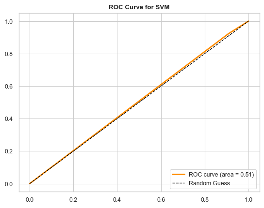

```python
fpr, tpr, thresholds = roc_curve(y_test, y_pred_svm)
roc_auc_svm = roc_auc_score(y_test, y_pred_svm)

plot.figure()
plot.plot(fpr, tpr, color='darkorange', lw=2, label='ROC curve (area = %0.2f)' % roc_auc_svm)
plot.plot([0, 1], [0, 1], color='black', lw=1, linestyle='--', label='Random Guess')
plot.legend(loc='lower right')
plot.grid(True)
plot.title("ROC Curve for SVM", fontdict = {"fontweight": "bold"})
plot.show()
```

## References

1. Ramana,Bendi and Venkateswarlu,N.. (2012). ILPD (Indian Liver Patient Dataset). UCI Machine Learning Repository. https://doi.org/10.24432/C5D02C.
2. Straw, I., & Wu, H. (2022). Investigating for bias in healthcare algorithms: a sex-stratified analysis of supervised machine learning models in liver disease prediction. BMJ Health & Care Informatics, 29.

## Appendix: individual plots for the presentation

[output not shown]

[figure not shown]

[figure not shown]

[figure not shown]

[figure not shown]

[figure not shown]

[figure not shown]

[figure not shown]

[figure not shown]

[figure not shown]

[figure not shown]

```python
exclude = ["Gender", "Selector"]
continuous = [col for col in liver_data.columns if col not in exclude]

for column in continuous:
    figure, axes = plot.subplots(1, 2, figsize=(16, 4))
    axes = axes.flatten()
    for i, axes in enumerate(axes):
        # Plot boxplot
        if i % 2 == 0:
            seaborn.boxplot(x=liver_data[column], ax=axes, palette = 'YlGnBu', y="Gender", data=liver_data)
            axes.set_title(f'Boxplot for {column}', fontdict={'fontweight': 'bold'})
        else:
            seaborn.histplot(x=liver_data[column], ax=axes, kde=True, hue="Gender", palette = 'YlGnBu', data=liver_data)
            axes.set_title(f'Histogram for {column}', fontdict={'fontweight': 'bold'})

# figure, axes = plot.subplots(len(continuous), 2, figsize=(15, 3 * len(continuous)))
# axes = axes.flatten()

# for i, axes in enumerate(axes):
#     # Plot boxplot
#     if i % 2 == 0:
#         seaborn.boxplot(x=liver_data[continuous[i // 2]], ax=axes, palette = 'YlGnBu', y="Gender", data=liver_data)
#         axes.set_title(f'Boxplot for {continuous[i // 2]}', fontdict={'fontweight': 'bold'})
#     # # Plot histogram
#     else:
#         seaborn.histplot(x=liver_data[continuous[i // 2]], ax=axes, kde=True, hue="Gender", palette = 'YlGnBu', data=liver_data)
#         axes.set_title(f'Histogram for {continuous[i // 2]}', fontdict={'fontweight': 'bold'})

# plot.subplots_adjust(hspace=0.5)  # Adjust the spacing between rows
```